# Fine-tuned GPT 3.5 for Boosting the Performance of Large Language Models for Question Answering with Knowledge Graph Integration

by Mingze Li

In this file, we need to first process the fine-tuning dataset, then fine-tune the model and finally process the QA tasks with a given dataset contains quesions and contexts.

```python
import tiktoken # for token counting
import numpy as np
import json
from collections import defaultdict
```

## Data analysis for chat model fine-tuning

We have generated the jsonl file for the fine-tuning and we must make sure the dataset can fit the model in the correct format. Those codes for Data Analysis are supported by Data preparation and analysis for chat model fine-tuning: https://cookbook.openai.com/examples/chat_finetuning_data_prep

```python
data_path = r"C:\Users\Li\Desktop\fine_tuning_database.jsonl"

# Load the dataset
with open(data_path, 'r', encoding='utf-8') as f:
    dataset = [json.loads(line) for line in f]

# Initial dataset stats
print("Num examples:", len(dataset))
print("First example:")
for message in dataset[0]["messages"]:
    print(message)
```

```
Num examples: 22
First example:
{'role': 'system', 'content': "You are a helpful assistant. Extract and answer using key information from context. Ensure the response is concise, without duplicates, focusing solely on crucial details. There are two examples: Example 1: (Context: The sun is a star in the center of our solar system.…
{'role': 'user', 'content': 'Context: Prof. Stefan Diebels has expertise in Computational materials science; PD Dr.  Franz  Roters has expertise in Computational materials science; EQ2PC has discipline Computational materials science; Prof. Dr. Karsten  Durst has expertise in Computational Materials…
{'role': 'assistant', 'content': 'Prof. Stefan Diebels; PD Dr.  Franz  Roters; Prof. Dr. Karsten  Durst'}
```

```python
# Format error checks
format_errors = defaultdict(int)

# Add a list to record the index of the wrong example
missing_assistant_examples = []

for i, ex in enumerate(dataset):
    if not isinstance(ex, dict):
        format_errors["data_type"] += 1
        continue

    messages = ex.get("messages", None)
    if not messages:
        format_errors["missing_messages_list"] += 1
        continue

    for message in messages:
        if "role" not in message or "content" not in message:
            format_errors["message_missing_key"] += 1
            print("errin index:", i)
            print("message: ",message)

        if any(k not in ("role", "content", "name", "function_call") for k in message):
            format_errors["message_unrecognized_key"] += 1
            print("errin index:", i)
            print("message: ",message)

        if message.get("role", None) not in ("system", "user", "assistant", "function"):
            format_errors["unrecognized_role"] += 1
            print("errin index:", i)
            print("message: ",message)

        content = message.get("content", None)
        function_call = message.get("function_call", None)

        if (not content and not function_call) or not isinstance(content, str):
            format_errors["missing_content"] += 1
            print("errin index:", i)
            print("message: ",messages)

    if not any(message.get("role", None) == "assistant" for message in messages):
        format_errors["example_missing_assistant_message"] += 1
        missing_assistant_examples.append(i)  # 记录发生错误的例子的索引
        print("errin index:", i)


if format_errors:
    print("Found errors:")
    for k, v in format_errors.items():
        print(f"{k}: {v}")
    if missing_assistant_examples:
        print("Missing assistant messages in examples:", missing_assistant_examples)
else:
    print("No errors found")
```

```
No errors found
```

```python
encoding = tiktoken.get_encoding("cl100k_base")

# not exact!
# simplified from https://github.com/openai/openai-cookbook/blob/main/examples/How_to_count_tokens_with_tiktoken.ipynb
def num_tokens_from_messages(messages, tokens_per_message=3, tokens_per_name=1):
    num_tokens = 0
    for message in messages:
        num_tokens += tokens_per_message
        for key, value in message.items():
            num_tokens += len(encoding.encode(value))
            if key == "name":
                num_tokens += tokens_per_name
    num_tokens += 3
    return num_tokens

def num_assistant_tokens_from_messages(messages):
    num_tokens = 0
    for message in messages:
        if message["role"] == "assistant":
            num_tokens += len(encoding.encode(message["content"]))
    return num_tokens

def print_distribution(values, name):
    print(f"\n#### Distribution of {name}:")
    print(f"min / max: {min(values)}, {max(values)}")
    print(f"mean / median: {np.mean(values)}, {np.median(values)}")
    print(f"p5 / p95: {np.quantile(values, 0.1)}, {np.quantile(values, 0.9)}")
```

```python
# Warnings and tokens counts
n_missing_system = 0
n_missing_user = 0
n_messages = []
convo_lens = []
assistant_message_lens = []

for ex in dataset:
    messages = ex["messages"]
    if not any(message["role"] == "system" for message in messages):
        n_missing_system += 1
    if not any(message["role"] == "user" for message in messages):
        n_missing_user += 1
    n_messages.append(len(messages))
    convo_lens.append(num_tokens_from_messages(messages))
    assistant_message_lens.append(num_assistant_tokens_from_messages(messages))

print("Num examples missing system message:", n_missing_system)
print("Num examples missing user message:", n_missing_user)
print_distribution(n_messages, "num_messages_per_example")
print_distribution(convo_lens, "num_total_tokens_per_example")
print_distribution(assistant_message_lens, "num_assistant_tokens_per_example")
n_too_long = sum(l > 4096 for l in convo_lens)
print(f"\n{n_too_long} examples may be over the 4096 token limit, they will be truncated during fine-tuning")
```

```
Num examples missing system message: 0
Num examples missing user message: 0

#### Distribution of num_messages_per_example:
min / max: 3, 3
mean / median: 3.0, 3.0
p5 / p95: 3.0, 3.0

#### Distribution of num_total_tokens_per_example:
min / max: 254, 3463
mean / median: 570.5454545454545, 390.5
p5 / p95: 280.6, 690.0000000000001

#### Distribution of num_assistant_tokens_per_example:
min / max: 2, 97
mean / median: 18.227272727272727, 8.5
p5 / p95: 3.0, 32.7

0 examples may be over the 4096 token limit, they will be truncated during fine-tuning
```

```python
# Pricing and default n_epochs estimate
MAX_TOKENS_PER_EXAMPLE = 4096

TARGET_EPOCHS = 3
MIN_TARGET_EXAMPLES = 100
MAX_TARGET_EXAMPLES = 25000
MIN_DEFAULT_EPOCHS = 1
MAX_DEFAULT_EPOCHS = 25

n_epochs = TARGET_EPOCHS
n_train_examples = len(dataset)
if n_train_examples * TARGET_EPOCHS < MIN_TARGET_EXAMPLES:
    n_epochs = min(MAX_DEFAULT_EPOCHS, MIN_TARGET_EXAMPLES // n_train_examples)
elif n_train_examples * TARGET_EPOCHS > MAX_TARGET_EXAMPLES:
    n_epochs = max(MIN_DEFAULT_EPOCHS, MAX_TARGET_EXAMPLES // n_train_examples)

n_billing_tokens_in_dataset = sum(min(MAX_TOKENS_PER_EXAMPLE, length) for length in convo_lens)
print(f"Dataset has ~{n_billing_tokens_in_dataset} tokens that will be charged for during training")
print(f"By default, you'll train for {n_epochs} epochs on this dataset")
print(f"By default, you'll be charged for ~{n_epochs * n_billing_tokens_in_dataset} tokens")
```

```
Dataset has ~12552 tokens that will be charged for during training
By default, you'll train for 4 epochs on this dataset
By default, you'll be charged for ~50208 tokens
```

## Fine tuning

```python
file_path = data_path
```

### upload the fine tuning dataset

In this step we need to collect key variables for the fine-tuned model:

```
1.file_object_id
2.fine_tuning_job_id
3.fine_tuned_model_name
```

Note: If you want to fit the model with new datasets please open those blocks blew and reset key variables

```python
"""# open if you want to upload a new dataset

from openai import OpenAI
client = OpenAI()
# use English version: converted_messages_en.jsonl
file_object  = client.files.create(
  file=open(file_path, "rb"),# could be: #messages.jsonl,#converted_messages.jsonl,#test_messages.jsonl
  purpose="fine-tune"
)
print("file_object.id:",file_object.id)
file_object_id = file_object.id
file_object


# open when you want to upload new data for fine-tuning"""
```

[output not shown]

[output not shown]

```python
file_object_id = 'file-RFWxvsMTKaJuqT9JP5wxusip'#'file-MCDZL5lcwJ8fVLS5VnK9x5oz'#'file-RFWxvsMTKaJuqT9JP5wxusip'## change it if you want to upload a new dataset
```

### Fine-tuning model

```python
"""# open if you want to upload a new dataset
# open when you want to upload new data for fine-tuning
from openai import OpenAI
client = OpenAI()

fine_tuning_job = client.fine_tuning.jobs.create(
  training_file = file_object_id,
  model="gpt-3.5-turbo"
)
print(fine_tuning_job.id)
fine_tuning_job

#FineTuningJob(id='ftjob-2Lpyr3aaKh1qmUa2PiqOr9ma', created_at=1704830407, error=None, fine_tuned_model=None, finished_at=None, hyperparameters=Hyperparameters(n_epochs='auto', batch_size='auto', learning_rate_multiplier='auto'), model='gpt-3.5-turbo-0613', object='fine_tuning.job', organization_id='org-1RBrqOHK4MGbSBFmx0Tqvb1b', result_files=[], status='validating_files', trained_tokens=None, training_file='file-flA9y8B28JIGeZSq1nM8fPh9', validation_file=None)
"""
```

[output not shown]

[output not shown]

```python
fine_tuning_job_id = 'ftjob-OhMtkRxKZX1W1K0vNPaVsAKA'#"ftjob-WMVtrj0tCvTHA6F2H2M7Ugkj"#'ftjob-OhMtkRxKZX1W1K0vNPaVsAKA'#'ftjob-zOPXqFLDdV9OfQODCOcBOYAH' # change it if you want to upload a new dataset
```

```python
"""# open if you want to upload a new dataset
from openai import OpenAI
import time

client = OpenAI()

# Loop to check the status of the fine-tuning job
while True:
    fine_tuning_job = client.fine_tuning.jobs.retrieve(fine_tuning_job_id)
    if fine_tuning_job.status == 'succeeded':
        # The fine-tuning job is completed and the name of the fine-tuned model is obtained.
        fine_tuned_model_name = fine_tuning_job.fine_tuned_model
        print("finetunned model name:", fine_tuned_model_name)
        break
    elif fine_tuning_job.status == 'failed':
        print("Fine-tuning job failed.")
        break
    print("Wait for the fine-tuning job to complete...")
    time.sleep(60)
"""
```

[output not shown]

```python
fine_tuned_model_name ="ft:gpt-3.5-turbo-0125:personal::8yR07PVm" #"ft:gpt-3.5-turbo-0125:personal::8yjvAGTt"#"ft:gpt-3.5-turbo-0125:personal::8yR07PVm" #'ft:gpt-3.5-turbo-0125:personal::8y5QLwC3'# change it if you want to upload a new dataset
```

### Load the dataset contains quesions and contexts

If you have some new datasets please reload them here. Note: the number of questions must not less than the number of context

```python
import pandas as pd
path = r"C:\Users\Li\Desktop\train_8_without score.xlsx" #r"C:\Users\Li\Desktop\input.xlsx"
df = pd.read_excel(path)
df
```

|  | Competency Question | Ground Truth | Related Triples | Context | Predicted Answer |
| --- | --- | --- | --- | --- | --- |
| 0 | Who is working in the Computational Materials ... | PD Dr. habil. Thomas Hammerschmidt; Prof. Dr. ... | [('http://demo.fiz-karlsruhe.de/matwerk/E12452... | Pyiron YouTube channel has description "Welcom... | Prof. Dr.-Ing. Stephan Wulfinghoff is working ... |
| 1 | What are the research projects associated to E... | VIMMP (2018-2021); OYSTER (2017-2021); SimDOME... | [('http://demo.fiz-karlsruhe.de/matwerk/E11267... | Elemental Multiperspective Material Ontology (... | The research projects associated with EMMO can... |
| 2 | Who are the contributors of the data "datasets"? | Prof. Felix Fritzen <http://demo.fiz-karlsruhe... | [('http://demo.fiz-karlsruhe.de/matwerk/E10428... | Materials Data Repository has contributor Nati... | The contributors of the data "datasets" could ... |
| 3 | Who is working with Researcher "Ebrahim Norouz... | Prof. Dr. Harald Sack; Mirza Mohtashim Alam; D... | [('http://demo.fiz-karlsruhe.de/matwerk/E15879... | Ebrahim Norouzi has work package FIZ Karlsruhe... | I'm sorry, but I couldn't find any specific in... |
| 4 | who is the email address of "ParaView"? | support@kitware.com | [('https://schema.org/dateCreated', 'rdfs:comm... | dateCreated has comment "The date on which the... | I'm sorry, I cannot provide an email address f... |
| 5 | What are the affilliations of Volker Hofmann? | Forschungszentrum Jülich <http://demo.fiz-karl... | [('http://demo.fiz-karlsruhe.de/matwerk/E14531... | Dr. Tilmann Hickel has affiliation with Max-Pl... | The affiliation of Dr. Volker Hofmann is the F... |
| 6 | What is "Molecular Dynamics" Software? List th... | 1. Resource: http://demo.fiz-karlsruhe.de/matw... | [('http://demo.fiz-karlsruhe.de/matwerk/E55172... | OpenBIS has description "The openBIS platform... | Molecular Dynamics software are simulation pac... |
| 7 | What are pre- and post-processing tools for MD... | Pizza.py Toolkit; pyscal; ASE; MDTraj; freud | [('http://demo.fiz-karlsruhe.de/matwerk/E46999... | Graphical Interface for Materials Simulations ... | Pre- and post-processing tools for MD (molecul... |
| 8 | What are some workflow environments for comput... | Pyiron; AiiDA; SimStack | [('http://demo.fiz-karlsruhe.de/matwerk/E49750... | matminer has description "Python library for ... | Some common workflow environments for computat... |
| 9 | How should I cite pyiron? | "title = {pyiron: An integrated development en... | [('http://demo.fiz-karlsruhe.de/matwerk/E12466... | APT analysis using CompositionSpace and pyiron... | You can cite Pyiron using the following inform... |
| 10 | Where can I find a list of interatomic potenti... | Interatomic potentials repository (NIST); Open... | [('http://demo.fiz-karlsruhe.de/matwerk/E49950... | mendeleev has description "A python package f... | You can find a list of interatomic potentials ... |
| 11 | What are python libraries used for calculating... | Pyscal | [('http://demo.fiz-karlsruhe.de/matwerk/E10866... | Materials Commons has repository https://githu... | Some Python libraries that can be used for cal... |
| 12 | What are the electronic lab notebooks available? | Pasta ELN; eLabFTW; Karlsruhe Data Infrastruct... | [('https://w3id.org/skgo/modsci#LaboratoryInst... | Laboratory Instrument has type nan; electronic... | Some software for molecular dynamics simulatio... |
| 13 | What are the software for Molecular Dynamics (... | Calphy; Melting temperature computational work... | [('http://demo.fiz-karlsruhe.de/matwerk/E49750... | matminer has website https://hackingmaterials.... | Some of the ontologies in the nanomaterials do... |
| 14 | What are the ontologies in nanomaterials domain? | MaterialsMine (MM); NanoParticle Ontology for ... | [('http://demo.fiz-karlsruhe.de/matwerk/E12452... | Knowledge Graphs (openHPI Massive Open Online ... | In the nanomaterials domain, some of the ontol... |
| 15 | What is DAMASK? | DAMASK is a unified multi-physics crystal plas... | [('http://demo.fiz-karlsruhe.de/matwerk/E45653... | Dusseldorf Advanced Material Simulation Kit ha... | DAMASK stands for Dusseldorf Advanced Material... |
| 16 | What are the data portals for materials scienc... | MatPortal | [('http://demo.fiz-karlsruhe.de/matwerk/E11282... | MaterialsMine (MM) has repository https://gith... | The data portals for materials science ontolog... |
| 17 | What are the instruments for APT? | No Answer | [(':n80e2298a963740ea9bdff3f1a27d3951b27', 'rd... | :n80e2298a963740ea9bdff3f1a27d3951b27 has firs... | APT, or Atom Probe Tomography, is an advanced... |
| 18 | In which institution can I find tomography equ... | 1. Procon CT-alpha"\n "X-ray micro computed to... | [] | NaN | You can find tomography equipment in instituti... |
| 19 | What are the educational resources for Ontology? | Knowledge Graphs (openHPI Massive Open Online ... | [('http://demo.fiz-karlsruhe.de/matwerk/E10298... | MatPortal has description "Ontology repository... | Educational resources for ontology are abundan... |
| 20 | What is the API of Materials Project? | https://api.materialsproject.org/docs | [('http://demo.fiz-karlsruhe.de/matwerk/E47875... | Python Materials Genomics has repository https... | The API for the Materials Project can be acces... |
| 21 | Which simulation software have a python API? | EMMOntoPy | [('http://demo.fiz-karlsruhe.de/matwerk/E49750... | matminer has description "Python library for ... | The Atomic Simulation Environment (ASE) is the... |
| 22 | What is the documentation of the "MatDB Online"? | https://publications.jrc.ec.europa.eu/reposito... | [('http://demo.fiz-karlsruhe.de/matwerk/E10399... | MatDB has description "MatDB is a database app... | The documentation for "MatDB Online" can be fo... |
| 23 | What are the types of software licenses? | BSD-3-Clause license; GPL 3 License; ASL/ BSD-... | [('http://purls.helmholtz-metadaten.de/mwo/has... | has format has type nan; Propietary has type P... | There are a few common types of software licen... |
| 24 | What are the software used to produce the data... | pymatgen; AiiDA; Quantum Espresso | [('http://demo.fiz-karlsruhe.de/matwerk/E55172... | OpenBIS has description "The openBIS platform... | The software used to produce the data in the M... |
| 25 | What are datasets produced by the BAM organiza... | BAM reference data: results of ASTM E139 -11 c... | [('http://demo.fiz-karlsruhe.de/matwerk/E10675... | The Materials Data Facility (MDF) has descript... | I'm sorry, I currently do not have direct acce... |
| 26 | What are some available datasets of mechanical... | Full dataset of several mechanical tests on an... | [('http://demo.fiz-karlsruhe.de/matwerk/E10500... | Diffusion Database (Kakusan) has description "... | There are several available datasets of mechan... |
| 27 | What are datasets related to "Transmission ele... | Radii of S-phase Al2CuMg in Al-alloy EN AW-261... | [('http://demo.fiz-karlsruhe.de/matwerk/E10689... | Material Properties Open Database (MPOD) has d... | There are various datasets related to transmis... |
| 28 | What is the license of the dataset "Elastic Co... | BSD 3-Clause License | [('http://demo.fiz-karlsruhe.de/matwerk/E11600... | NeXus Data Format has license LGPL-2.1 license... | The license for the dataset "Elastic Constant ... |
| 29 | What is the repository for "BAM reference data"? | http://demo.fiz-karlsruhe.de/matwerk/E291704; ... | [('http://demo.fiz-karlsruhe.de/matwerk/E11737... | BAM reference data: results of ASTM E139 -11 c... | The repository for "BAM reference data" could ... |
| 30 | What are the different data formats in the "BA... | csv; pdf | [('http://demo.fiz-karlsruhe.de/matwerk/E11737... | BAM reference data: results of ASTM E139 -11 c... | The different data formats in the "BAM referen... |
| 31 | What is the software version of "pacemaker"? | 0.2.7 | [('http://demo.fiz-karlsruhe.de/matwerk/E11554... | Graphical Expression of Materials Data (GEMD) ... | The software version of "pacemaker" can be fou... |
| 32 | What is the field of research "BAM reference d... | high temperature mechanical behavior | [('http://demo.fiz-karlsruhe.de/matwerk/E11737... | BAM reference data: results of ASTM E139 -11 c... | The field of research "BAM reference data" app... |
| 33 | What is the description of the "BAM reference ... | The creep behavior of a certified reference ma... | [('http://demo.fiz-karlsruhe.de/matwerk/E11737... | BAM reference data: results of ASTM E139 -11 c... | The description of "BAM reference data" is tha... |
| 34 | What are the datasets produced in 2022? | Brinell-Hardness (HBW 2.5/62.5) of Al-alloy EN... | [] | NaN | Based on the information provided, it seems li... |
| 35 | Who is the creators of the "BAM reference data"? | Sina Schriever (http://demo.fiz-karlsruhe.de/m... | [('http://demo.fiz-karlsruhe.de/matwerk/E11737... | BAM reference data: results of ASTM E139 -11 c... | The creator of the "BAM reference data" is no... |
| 36 | What are the datasets published by "BAM"? | Datasets for the analysis of dislocations at g... | [('http://demo.fiz-karlsruhe.de/matwerk/E55172... | OpenBIS has description "The openBIS platform... | I'm sorry, but I'm unable to provide specific ... |
| 37 | Average | NaN | NaN | NaN | These are just a few examples, and there are m... |

```python
questions = df['Competency Question']
contexts = df['Context']
length = questions.count()
print(questions.count())
print(contexts.count())
```

```
38
35
```

## QA tasks based on the fine-tuned model

```python
import os
from openai import OpenAI
import openai

def get_answer_with_single_question(question, context):

    # Set OpenAI API key
    api_key = os.environ.get('OPENAI_API_KEY')
    openai.api_key = api_key

    # Initialize OpenAI client
    client = OpenAI(api_key=api_key)

    # Set up the model
    model= fine_tuned_model_name #'gpt-3.5-turbo-1106'

    try:
        messages=[
                    {"role": "system", "content": "You are a helpful assistant. Extract and answer using key information from context. Ensure the response is concise, without duplicates, focusing solely on crucial details. There are two examples: Example 1: (Context: The sun is a star in the center of our solar system.Question: What is the sun? Answer: A star at the center of the solar system.) and Example 2: (Context: Neil Armstrong was the first person to walk on the moon. Question: Who was the first person to walk on the moon? Answer: Neil Armstrong.). Your answer must be provided in a direct and concise format, without using any lead-in phrases such as 'Answer:' or similar. Only the answer itself should be included in the response. "},
                    # instruction
                    {"role": "user", "content": "Context: " + context + " Question:" + question}
        ]
        response = client.chat.completions.create(
            model=model,
            messages=messages
        )

        # Extract and return the answer
        answer = response.choices[0].message.content
        return answer

    except Exception as e:
        print(f"An error occurred while processing the problem: {e}")
        return "Unable to get answer"
```

```python
from openai import OpenAI
import openai
import os


# Set OpenAI API key
api_key = os.environ.get('OPENAI_API_KEY')
openai.api_key = api_key

# Initialize OpenAI client
client = OpenAI(api_key=api_key)

# Set up the model
model = fine_tuned_model_name #'gpt-3.5-turbo-1106'

user_input_count = 0
arr_answers = []

for i in range(length):
    if contexts[i] == "":
        user_input_count += 1
        continue
    print(f"No. {user_input_count} question: {questions[i]}")
    print(f"No. {user_input_count} context: {contexts[i]}")
    answer = get_answer_with_single_question(questions[i], contexts[i])
    arr_answers.append(answer)
    print(f"No. {user_input_count} answer: {answer}")
    user_input_count += 1
```

```
No. 0 question: Who is working in the Computational Materials Science field?
No. 0 context: Pyiron YouTube channel has description "Welcome to our youtube channel where we present pyiron - an integrated development environment for computational materials science. "; MaterialsMine (MM) has description "A materials ontology to support data publication involving nanomaterials a…
No. 0 answer: Prof. Dr. Karsten Durst; Prof. Dr.-Ing. Stephan Wulfinghoff; Christian Dorn; Dr.-Ing Abril Azocar Guzman; Prof. Dr. Jörg Neugebauer; Prof. Stefan Diebels; PD Dr. Franz Roters; PD Dr. habil. Thomas Hammerschmidt; Dr. Sarath Menon
No. 1 question: What are the research projects associated to EMMO?
No. 1 context: Elemental Multiperspective Material Ontology (EMMO) has related Project EMMC-CSA (2016-2019); Elemental Multiperspective Material Ontology (EMMO) has related Project SimDOME (2019-2023); Elemental Multiperspective Material Ontology (EMMO) has related Project MarketPlace (2018-2022); E…
No. 1 answer: Project EMMC-CSA (2016-2019); SimDOME (2019-2023); MarketPlace (2018-2022); VIMMP (2018-2021); OntoTrans (2020-2024); ReaxPro (2019-2023); OntoCommons (2020-2023); OYSTER (2017-2021); NanoMECommons (2021-2025); OpenModel (2021-2025)
No. 2 question: Who are the contributors of the data "datasets"?
No. 2 context: Materials Data Repository has contributor National Institute for Materials Science (NIMS), Japan; Materials Data Repository has description "MDR is a data repository to collect and store papers, presentation materials, and related materials data to accumulate and release them in a for…
No. 2 answer: Fernández; Prof. Felix Fritzen; Oliver Weeger; Frederik Larsson
No. 3 question: Who is working with Researcher "Ebrahim Norouzi" in the same group?
No. 3 context: Ebrahim Norouzi has work package FIZ Karlsruhe - Leibniz Institute for Information Infrastructure; Dr. Jörg Waitelonis has work package FIZ Karlsruhe - Leibniz Institute for Information Infrastructure; Dr.  Heike Fliegl has work package FIZ Karlsruhe - Leibniz Institute for Informatio…
No. 3 answer: Mirza Mohtashim Alam
No. 4 question: who is the email address of "ParaView"?
No. 4 context: dateCreated has comment "The date on which the CreativeWork was created or the item was added to a DataFeed."; dateCreated has domain resource; dataset has comment "A dataset is associated with a structured information about a resource."; about material has domain dataset; has creator…
No. 4 answer: support@kitware.com
No. 5 question: What are the affilliations of Volker Hofmann?
No. 5 context: Dr. Tilmann Hickel has affiliation with Max-Planck-Institut für Eisenforschung; Dr. Tilmann Hickel has affiliation with Bundesanstalt für Materialforschung und -prüfung; PD Dr.  Franz  Roters has affiliation with Max-Planck-Institut für Eisenforschung; Prof. Dr. Erik Bitzek has affili…
No. 5 answer: Forschungszentrum Jülich
No. 6 question: What is "Molecular Dynamics" Software? List the programming language, documentation page, repository, and license information.
No. 6 context: OpenBIS has  description "The openBIS platform has three primary functionalities: 1. Inventory management of laboratory samples, materials, protocols, equipment. 2. Laboratory notebook, to document lab experiments. 3. Data management, to store all data related to lab experiments (raw,…
  H.J.C. Berendsen, D. van der Spoel and R. van Drunen_x000D_
  Comp. Phys. Comm. 91, 43-56 (1995)_x000D_
  DOI: https://doi.org/10.1016/0010-4655(95)00042-E_x000D_
 _x000D_
* GROMACS 4: Algorithms for highly efficient, load-balanced, and scalable_x000D_
  molecular simulation_x000D_
  B. Hess and C. Kutzner and D. van der Spoel and E. Lindahl_x000D_
  J. Chem. Theory Comput. 4 (2008) pp. 435-447_x000D_
  DOI: https://doi.org/10.1021/ct700301q_x000D_
_x000D_
* GROMACS 4.5: a high-throughput and highly parallel open source_x000D_
  molecular simulation toolkit_x000D_
  Sander Pronk, Szilárd Páll, Roland Schulz, Per Larsson, Pär Bjelkmar,_x000D_
  Rossen Apostolov, Michael R. Shirts, Jeremy C. Smith, Peter M. Kasson,_x000D_
  David van der Spoel, Berk Hess, Erik Lindahl._x000D_
  Bioinformatics 29 (2013) pp. 845-54_x000D_
  DOI: https://doi.org/10.1093/bioinformatics/btt055_x000D_
_x000D_
* Tackling Exascale Software Challenges in Molecular Dynamics Simulations_x000D_
  with GROMACS_x000D_
```

[output cut: 154 more lines]

```
No. 35 context: BAM reference data: results of ASTM E139 -11 creep tests on a reference material of Nimonic 75 nickel-base alloy has creator Sina Schriever; BAM reference data: results of ASTM E139 -11 creep tests on a reference material of Nimonic 75 nickel-base alloy has creator Prof. Birgit Skrot…
of the Electronic Structure Common Data Format (ESCDF), an initiative of the
Electronic Structure Library (ESL) Contributors.
"; The MatWerk ontology has  description "The MatWerk ontology represents research data and related activities of the MSE community. A first version of the ontology will be simplified, focusing on (i) community structure: researchers, research projects, universities, and institutions; (ii) infrastru…
No. 35 answer: Sina Schriever; Prof. Birgit Skrotzki
No. 36 question: What are the datasets published by "BAM"?
No. 36 context: OpenBIS has  description "The openBIS platform has three primary functionalities: 1. Inventory management of laboratory samples, materials, protocols, equipment. 2. Laboratory notebook, to document lab experiments. 3. Data management, to store all data related to lab experiments (raw…
of the Electronic Structure Common Data Format (ESCDF), an initiative of the
Electronic Structure Library (ESL) Contributors.
"; Materials Data Repository has description "MDR is a data repository to collect and store papers, presentation materials, and related materials data to accumulate and release them in a form suitable for the promotion of materials research and materials informatics. Users can search the documents a…
No. 36 answer: Bundesanstalt für Materialforschung und -prüfung (BAM)
No. 37 question: Average
No. 37 context: nan
An error occurred while processing the problem: can only concatenate str (not "float") to str
No. 37 answer: Unable to get answer
```

```python
arr_answers
```

```
['Prof. Dr. Karsten Durst; Prof. Dr.-Ing. Stephan Wulfinghoff; Christian Dorn; Dr.-Ing Abril Azocar Guzman; Prof. Dr. Jörg Neugebauer; Prof. Stefan Diebels; PD Dr. Franz Roters; PD Dr. habil. Thomas Hammerschmidt; Dr. Sarath Menon',
 'Project EMMC-CSA (2016-2019); SimDOME (2019-2023); MarketPlace (2018-2022); VIMMP (2018-2021); OntoTrans (2020-2024); ReaxPro (2019-2023); OntoCommons (2020-2023); OYSTER (2017-2021); NanoMECommons (2021-2025); OpenModel (2021-2025)',
 'Fernández; Prof. Felix Fritzen; Oliver Weeger; Frederik Larsson',
 'Mirza Mohtashim Alam',
 'support@kitware.com',
 'Forschungszentrum Jülich',
 'GROMACS; Programming Language: C, C++; Documentation: DOI links provided; Repository: maintained by developers; License: GNU Lesser General Public License',
 'Pizza.py Toolkit',
 'matminer, Simmate, Pyiron',
 'Jan Janssen and colleagues.',
 'Interatomic potentials repository (NIST)',
 'Pyscal',
 'nan',
 'dynasor; freud',
 'MaterialsMine (MM)\nMaterials Design Ontology (MDO)\nMaterials And Molecules Basic Ontology (MAMBO)\neNanoMapper ontology',
 'A unified multi-physics crystal plasticity simulation package',
 'MatPortal',
 'Instrument',
 'Unable to get answer',
 'Infrastructure: software, workflows, ontologies, schemas, APIs, instruments, facilities, educational resources',
 'https://pymatgen.org/',
 'pycp2k',
 'https://publications.jrc.ec.europa.eu/repository/handle/JRC75978',
 'Proprietary commercial software license',
 'Materials Cloud',
 'Framework for curation and distribution of reference datasets',
 'MatDat',
 'pySTEM',
 'BSD 3-Clause License',
 'https://doi.org/10.5281/zenodo.5106606',
 'csv; pdf',
 '0.2.7',
 'high temperature mechanical behavior',
 'The creep behavior of a certified reference material was determined according to ASTM E139-11 using calibrated equipment of an accredited testing laboratory',
 'Unable to get answer',
 'Sina Schriever; Prof. Birgit Skrotzki',
 'Bundesanstalt für Materialforschung und -prüfung (BAM)',
 'Unable to get answer']
```

```python
df['answer_text'] = arr_answers
df
```

|  | Competency Question | Ground Truth | Related Triples | Context | Predicted Answer | answer_text |
| --- | --- | --- | --- | --- | --- | --- |
| 0 | Who is working in the Computational Materials ... | PD Dr. habil. Thomas Hammerschmidt; Prof. Dr. ... | [('http://demo.fiz-karlsruhe.de/matwerk/E12452... | Pyiron YouTube channel has description "Welcom... | Prof. Dr.-Ing. Stephan Wulfinghoff is working ... | Prof. Dr. Karsten Durst; Prof. Dr.-Ing. Stepha... |
| 1 | What are the research projects associated to E... | VIMMP (2018-2021); OYSTER (2017-2021); SimDOME... | [('http://demo.fiz-karlsruhe.de/matwerk/E11267... | Elemental Multiperspective Material Ontology (... | The research projects associated with EMMO can... | Project EMMC-CSA (2016-2019); SimDOME (2019-20... |
| 2 | Who are the contributors of the data "datasets"? | Prof. Felix Fritzen <http://demo.fiz-karlsruhe... | [('http://demo.fiz-karlsruhe.de/matwerk/E10428... | Materials Data Repository has contributor Nati... | The contributors of the data "datasets" could ... | Fernández; Prof. Felix Fritzen; Oliver Weeger;... |
| 3 | Who is working with Researcher "Ebrahim Norouz... | Prof. Dr. Harald Sack; Mirza Mohtashim Alam; D... | [('http://demo.fiz-karlsruhe.de/matwerk/E15879... | Ebrahim Norouzi has work package FIZ Karlsruhe... | I'm sorry, but I couldn't find any specific in... | Mirza Mohtashim Alam |
| 4 | who is the email address of "ParaView"? | support@kitware.com | [('https://schema.org/dateCreated', 'rdfs:comm... | dateCreated has comment "The date on which the... | I'm sorry, I cannot provide an email address f... | support@kitware.com |
| 5 | What are the affilliations of Volker Hofmann? | Forschungszentrum Jülich <http://demo.fiz-karl... | [('http://demo.fiz-karlsruhe.de/matwerk/E14531... | Dr. Tilmann Hickel has affiliation with Max-Pl... | The affiliation of Dr. Volker Hofmann is the F... | Forschungszentrum Jülich |
| 6 | What is "Molecular Dynamics" Software? List th... | 1. Resource: http://demo.fiz-karlsruhe.de/matw... | [('http://demo.fiz-karlsruhe.de/matwerk/E55172... | OpenBIS has description "The openBIS platform... | Molecular Dynamics software are simulation pac... | GROMACS; Programming Language: C, C++; Documen... |
| 7 | What are pre- and post-processing tools for MD... | Pizza.py Toolkit; pyscal; ASE; MDTraj; freud | [('http://demo.fiz-karlsruhe.de/matwerk/E46999... | Graphical Interface for Materials Simulations ... | Pre- and post-processing tools for MD (molecul... | Pizza.py Toolkit |
| 8 | What are some workflow environments for comput... | Pyiron; AiiDA; SimStack | [('http://demo.fiz-karlsruhe.de/matwerk/E49750... | matminer has description "Python library for ... | Some common workflow environments for computat... | matminer, Simmate, Pyiron |
| 9 | How should I cite pyiron? | "title = {pyiron: An integrated development en... | [('http://demo.fiz-karlsruhe.de/matwerk/E12466... | APT analysis using CompositionSpace and pyiron... | You can cite Pyiron using the following inform... | Jan Janssen and colleagues. |
| 10 | Where can I find a list of interatomic potenti... | Interatomic potentials repository (NIST); Open... | [('http://demo.fiz-karlsruhe.de/matwerk/E49950... | mendeleev has description "A python package f... | You can find a list of interatomic potentials ... | Interatomic potentials repository (NIST) |
| 11 | What are python libraries used for calculating... | Pyscal | [('http://demo.fiz-karlsruhe.de/matwerk/E10866... | Materials Commons has repository https://githu... | Some Python libraries that can be used for cal... | Pyscal |
| 12 | What are the electronic lab notebooks available? | Pasta ELN; eLabFTW; Karlsruhe Data Infrastruct... | [('https://w3id.org/skgo/modsci#LaboratoryInst... | Laboratory Instrument has type nan; electronic... | Some software for molecular dynamics simulatio... | nan |
| 13 | What are the software for Molecular Dynamics (... | Calphy; Melting temperature computational work... | [('http://demo.fiz-karlsruhe.de/matwerk/E49750... | matminer has website https://hackingmaterials.... | Some of the ontologies in the nanomaterials do... | dynasor; freud |
| 14 | What are the ontologies in nanomaterials domain? | MaterialsMine (MM); NanoParticle Ontology for ... | [('http://demo.fiz-karlsruhe.de/matwerk/E12452... | Knowledge Graphs (openHPI Massive Open Online ... | In the nanomaterials domain, some of the ontol... | MaterialsMine (MM)\nMaterials Design Ontology ... |
| 15 | What is DAMASK? | DAMASK is a unified multi-physics crystal plas... | [('http://demo.fiz-karlsruhe.de/matwerk/E45653... | Dusseldorf Advanced Material Simulation Kit ha... | DAMASK stands for Dusseldorf Advanced Material... | A unified multi-physics crystal plasticity sim... |
| 16 | What are the data portals for materials scienc... | MatPortal | [('http://demo.fiz-karlsruhe.de/matwerk/E11282... | MaterialsMine (MM) has repository https://gith... | The data portals for materials science ontolog... | MatPortal |
| 17 | What are the instruments for APT? | No Answer | [(':n80e2298a963740ea9bdff3f1a27d3951b27', 'rd... | :n80e2298a963740ea9bdff3f1a27d3951b27 has firs... | APT, or Atom Probe Tomography, is an advanced... | Instrument |
| 18 | In which institution can I find tomography equ... | 1. Procon CT-alpha"\n "X-ray micro computed to... | [] | NaN | You can find tomography equipment in instituti... | Unable to get answer |
| 19 | What are the educational resources for Ontology? | Knowledge Graphs (openHPI Massive Open Online ... | [('http://demo.fiz-karlsruhe.de/matwerk/E10298... | MatPortal has description "Ontology repository... | Educational resources for ontology are abundan... | Infrastructure: software, workflows, ontologie... |
| 20 | What is the API of Materials Project? | https://api.materialsproject.org/docs | [('http://demo.fiz-karlsruhe.de/matwerk/E47875... | Python Materials Genomics has repository https... | The API for the Materials Project can be acces... | https://pymatgen.org/ |
| 21 | Which simulation software have a python API? | EMMOntoPy | [('http://demo.fiz-karlsruhe.de/matwerk/E49750... | matminer has description "Python library for ... | The Atomic Simulation Environment (ASE) is the... | pycp2k |
| 22 | What is the documentation of the "MatDB Online"? | https://publications.jrc.ec.europa.eu/reposito... | [('http://demo.fiz-karlsruhe.de/matwerk/E10399... | MatDB has description "MatDB is a database app... | The documentation for "MatDB Online" can be fo... | https://publications.jrc.ec.europa.eu/reposito... |
| 23 | What are the types of software licenses? | BSD-3-Clause license; GPL 3 License; ASL/ BSD-... | [('http://purls.helmholtz-metadaten.de/mwo/has... | has format has type nan; Propietary has type P... | There are a few common types of software licen... | Proprietary commercial software license |
| 24 | What are the software used to produce the data... | pymatgen; AiiDA; Quantum Espresso | [('http://demo.fiz-karlsruhe.de/matwerk/E55172... | OpenBIS has description "The openBIS platform... | The software used to produce the data in the M... | Materials Cloud |
| 25 | What are datasets produced by the BAM organiza... | BAM reference data: results of ASTM E139 -11 c... | [('http://demo.fiz-karlsruhe.de/matwerk/E10675... | The Materials Data Facility (MDF) has descript... | I'm sorry, I currently do not have direct acce... | Framework for curation and distribution of ref... |
| 26 | What are some available datasets of mechanical... | Full dataset of several mechanical tests on an... | [('http://demo.fiz-karlsruhe.de/matwerk/E10500... | Diffusion Database (Kakusan) has description "... | There are several available datasets of mechan... | MatDat |
| 27 | What are datasets related to "Transmission ele... | Radii of S-phase Al2CuMg in Al-alloy EN AW-261... | [('http://demo.fiz-karlsruhe.de/matwerk/E10689... | Material Properties Open Database (MPOD) has d... | There are various datasets related to transmis... | pySTEM |
| 28 | What is the license of the dataset "Elastic Co... | BSD 3-Clause License | [('http://demo.fiz-karlsruhe.de/matwerk/E11600... | NeXus Data Format has license LGPL-2.1 license... | The license for the dataset "Elastic Constant ... | BSD 3-Clause License |
| 29 | What is the repository for "BAM reference data"? | http://demo.fiz-karlsruhe.de/matwerk/E291704; ... | [('http://demo.fiz-karlsruhe.de/matwerk/E11737... | BAM reference data: results of ASTM E139 -11 c... | The repository for "BAM reference data" could ... | https://doi.org/10.5281/zenodo.5106606 |
| 30 | What are the different data formats in the "BA... | csv; pdf | [('http://demo.fiz-karlsruhe.de/matwerk/E11737... | BAM reference data: results of ASTM E139 -11 c... | The different data formats in the "BAM referen... | csv; pdf |
| 31 | What is the software version of "pacemaker"? | 0.2.7 | [('http://demo.fiz-karlsruhe.de/matwerk/E11554... | Graphical Expression of Materials Data (GEMD) ... | The software version of "pacemaker" can be fou... | 0.2.7 |
| 32 | What is the field of research "BAM reference d... | high temperature mechanical behavior | [('http://demo.fiz-karlsruhe.de/matwerk/E11737... | BAM reference data: results of ASTM E139 -11 c... | The field of research "BAM reference data" app... | high temperature mechanical behavior |
| 33 | What is the description of the "BAM reference ... | The creep behavior of a certified reference ma... | [('http://demo.fiz-karlsruhe.de/matwerk/E11737... | BAM reference data: results of ASTM E139 -11 c... | The description of "BAM reference data" is tha... | The creep behavior of a certified reference ma... |
| 34 | What are the datasets produced in 2022? | Brinell-Hardness (HBW 2.5/62.5) of Al-alloy EN... | [] | NaN | Based on the information provided, it seems li... | Unable to get answer |
| 35 | Who is the creators of the "BAM reference data"? | Sina Schriever (http://demo.fiz-karlsruhe.de/m... | [('http://demo.fiz-karlsruhe.de/matwerk/E11737... | BAM reference data: results of ASTM E139 -11 c... | The creator of the "BAM reference data" is no... | Sina Schriever; Prof. Birgit Skrotzki |
| 36 | What are the datasets published by "BAM"? | Datasets for the analysis of dislocations at g... | [('http://demo.fiz-karlsruhe.de/matwerk/E55172... | OpenBIS has description "The openBIS platform... | I'm sorry, but I'm unable to provide specific ... | Bundesanstalt für Materialforschung und -prüfu... |
| 37 | Average | NaN | NaN | NaN | These are just a few examples, and there are m... | Unable to get answer |

## Dataframe saved as a XLSX file

```python
save_path = r"C:\Users\Li\Desktop\results_finetuned.xlsx"

df.to_excel(save_path, index=False)

print("successfully saved", save_path)
```

```
successfully saved C:\Users\Li\Desktop\results_finetuned.xlsx
```

# Evaluation

by Haoran Yang

```python
import pandas as pd
from rouge import Rouge
from nltk.translate.bleu_score import sentence_bleu
from sentence_transformers import SentenceTransformer, util

# Define paths
excel_file_path = save_path
output_file_path = r"C:\Users\Li\Desktop\results_finetuned_score.xlsx"

# Read Excel file
df = pd.read_excel(excel_file_path, usecols=['Competency Question', 'Context', 'Ground Truth', 'answer_text'])

# Initialize scorers
rouge = Rouge()
sbert_model = SentenceTransformer('all-MiniLM-L6-v2')

# Prepare a dictionary to store scores
scores_dict = {
    "ROUGE-1-f": [], "ROUGE-1-p": [], "ROUGE-1-r": [],
    "ROUGE-2-f": [], "ROUGE-2-p": [], "ROUGE-2-r": [],
    "ROUGE-L-f": [], "ROUGE-L-p": [], "ROUGE-L-r": [],
    "BLEU": [],
    "SBERT-Similarity": []
}

# Calculate scores
for _, row in df.iterrows():
    ground_truth = str(row['Ground Truth']) if not pd.isnull(row['Ground Truth']) else ""
    predicted_answer = str(row['answer_text']) if not pd.isnull(row['answer_text']) else ""

    # Calculate ROUGE scores
    if ground_truth and predicted_answer:
        rouge_scores = rouge.get_scores(predicted_answer, ground_truth)[0]
        for key in scores_dict:
            if key.startswith("ROUGE"):
                rouge_type, rouge_metric = key.split('-')[1], key.split('-')[2]
                scores_dict[key].append(rouge_scores['rouge-{}'.format(rouge_type.lower())][rouge_metric])
    else:
        for key in scores_dict:
            if key.startswith("ROUGE"):
                scores_dict[key].append(None)

    # Calculate BLEU score
    reference = ground_truth.split()
    candidate = predicted_answer.split()
    bleu_score = sentence_bleu([reference], candidate, weights=(0.25, 0.25, 0.25, 0.25)) if ground_truth and predicted_answer else None
    scores_dict["BLEU"].append(bleu_score)

    # Calculate SBERT-Similarity score
    if ground_truth and predicted_answer:
        embeddings1 = sbert_model.encode([ground_truth], convert_to_tensor=True)
        embeddings2 = sbert_model.encode([predicted_answer], convert_to_tensor=True)
        cos_sim = util.pytorch_cos_sim(embeddings1, embeddings2)
        scores_dict["SBERT-Similarity"].append(cos_sim.item())
    else:
        scores_dict["SBERT-Similarity"].append(None)

# Add scores to DataFrame
for key, value in scores_dict.items():
    df[key] = value

# Save to Excel file
df.to_excel(output_file_path, index=False)

print(f"Scores have been calculated and the results are saved to: {output_file_path}")
```

```
Scores have been calculated and the results are saved to: C:\Users\Li\Desktop\results_finetuned_score.xlsx
```

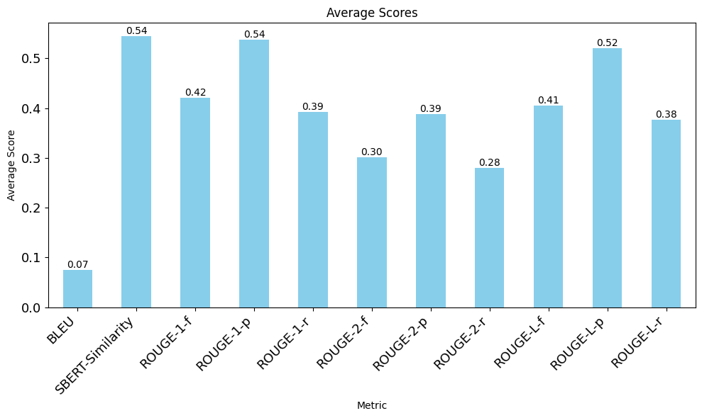

```python
import pandas as pd
import matplotlib.pyplot as plt

# Load Excel file

output_file_path = r"C:\Users\Li\Desktop\results_finetuned_score.xlsx"
df = pd.read_excel(output_file_path)

# Specify columns to compute mean
columns_to_mean = [
    'BLEU', 'SBERT-Similarity',
    'ROUGE-1-f', 'ROUGE-1-p', 'ROUGE-1-r',
    'ROUGE-2-f', 'ROUGE-2-p', 'ROUGE-2-r',
    'ROUGE-L-f', 'ROUGE-L-p', 'ROUGE-L-r'
]

# Compute mean
means = df[columns_to_mean].mean()

# Visualization
ax = means.plot(kind='bar', figsize=(10, 6), color='skyblue', fontsize=13)

plt.title('Average Scores')
plt.xlabel('Metric')
plt.ylabel('Average Score')
plt.xticks(rotation=45, ha='right')  # Rotate x-axis labels for readability
plt.tight_layout()  # Automatically adjust subplot parameters to give specified padding

# Add values above each bar
for i in ax.patches:
    ax.text(i.get_x() + i.get_width() / 2, i.get_height(), f'{i.get_height():.2f}', ha='center', va='bottom')

plt.show()
```